# Exercise 4: CART

Aparna Pandey, Marco Kreuzer & Stephan Peischl

IBU Machine Learning Summer School 2024, University of Bern

18.06.2024

In our previous lessons, we have explored classical statistical models, such as regressions. These models are based on fitting mathematical equations to data, allowing us to understand relationships and make predictions based on certain assumptions about the data distribution and underlying patterns. Classical models like linear and logistic regression are powerful tools but often rely on these assumptions being met for accurate results.

In machine learning, we often use models that are designed to be more flexible and make fewer assumptions about the data. One key feature of many machine learning models is their reliance on cross-validation. This technique is used to assess the performance of the models and how the models generalize to unseen data.

The first model to explore these concepts will be with decision trees. Decision trees are intuitive and powerful models that partition the data into subsets based on feature values, creating a tree-like structure of decisions. Unlike classical models, decision trees do not assume a specific form for the data, making them versatile for various types of data and problems.

By using cross-validation, we can fine-tune our decision tree models, balancing complexity and performance. This approach ensures we build models that not only fit our training data well but also perform effectively on new, unseen data.

## Data Manipulation

Load the data set.

```r
# load data
data <- read.table("data/baby.dat", header=TRUE)
```

Transoform data:

```r
# Find the index of the "Survival" column
label_index <- which(colnames(data) == "Survival")

# Rename the column to "labels" and convert it to a factor
colnames(data)[label_index] <- "labels"

data$labels = as.factor(data$labels)

numeric_variables <- data %>%
    select_if(~ !is.factor(.)) %>%
    colnames()
categorical_variables <- data %>%
    select_if(~ is.factor(.)) %>%
    colnames()
```

Split the data into train and test data set. Using separate train and test data when building CART models helps evaluate how well the model generalizes to new, unseen data, preventing overfitting. The training data is used to teach the model the underlying patterns, while the testing data provides an unbiased measure of its performance. This ensures the model’s accuracy and reliability in real-world applications.

In this example, we make a 70%, 30% split.

```r
# Split data into training and test data

training_index <- createDataPartition(data$labels ,
                                p = .7, list = FALSE,times = 1) %>%  as.numeric()

test_index <- which(!(seq_len(nrow(data)) %in% training_index))


training_data = data[training_index,]
test_data = data[test_index,]


# Assess the data split
table(training_data$labels)
```

```
##
##   0   1
##  61 113
```

```r
table(test_data$labels)
```

```
##
##  0  1
## 25 48
```

However, for training and testing the model, we want to balance the data. Balancing the dataset ensures that each class has an equal representation, which helps the model learn equally well for all classes and not be biased toward the majority class. In our example, balancing the training data by the minimum class size ensures fair training, while balancing the test data by the maximum class size provides a robust evaluation. This approach improves the model’s ability to generalize and make accurate predictions across all classes. Consequently, it prevents issues like overfitting to the majority class and enhances the reliability of the model’s performance.

```r
# balance the data set
training_data = training_data  %>%
balance(cat_col = "labels", size = "min")

test_data = test_data  %>%
balance(cat_col = "labels", size = "max")
```

We then also center and scale the data before fitting the model.

**Important** This is done after splitting the data. Otherwise we would introduce data leakage.

```r
# Center and scale the data
preproc <- preProcess(training_data, method = c("center","scale")) # note that factors are not transformed
pp_train <- predict(preproc, training_data) # centering and Scaling train set based on train data

preproc <- preProcess(test_data, method = c("center","scale")) # note that factors are not transformed
pp_test <- predict(preproc, test_data) # centering and Scaling test set based on test data

# Assess the data split
table(pp_train$labels)
```

```
##
##  0  1
## 61 61
```

```r
table(pp_test$labels)
```

```
##
##  0  1
## 48 48
```

## Data Modelling

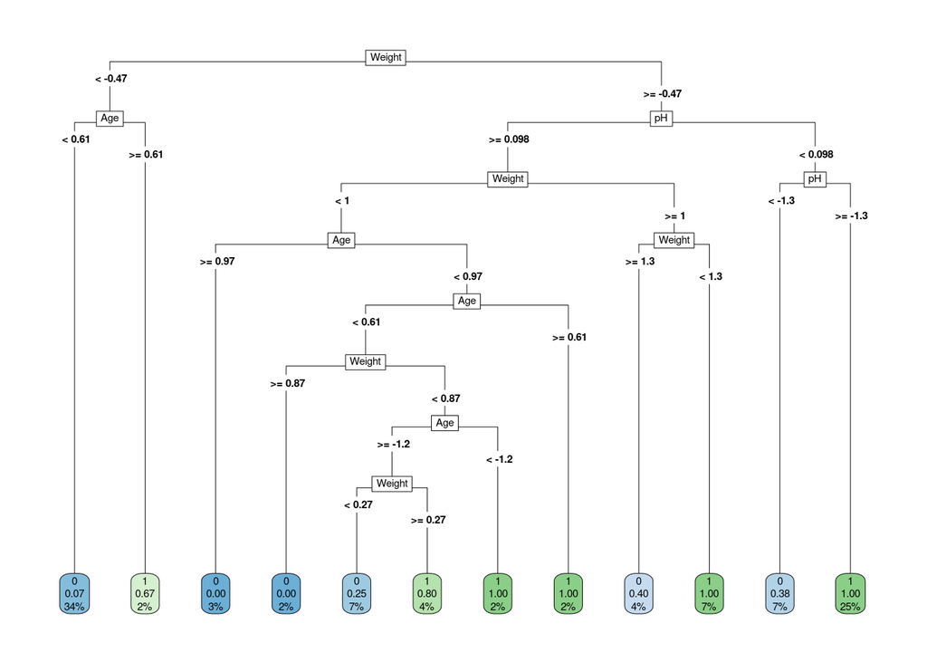

```r
# Fit a decision tree using the package rpart

# minsplit=10 sets the minimum number of observations required in a node in order for it to be split further.
mod = rpart(labels~.,minsplit=10,data=pp_train)

# Fit the model
# type = 5 indicates that the plot will include the split variable name in the interior nodes
rpart.plot(mod,type = 5)
```

We then calculate the classification performance:

```r
# calcualte misclassification rate:
pred = predict(mod,pp_test,type="class")
pred_in_sample = predict(mod,pp_train,type="class")

# Misclassification rate based on test data
mis_class_full = mean(pred != pp_test$labels)

# Misclassification rate  based on trainingt data (in-sample misclassification)
mis_class_full_in_sample =mean(pred_in_sample != pp_train$labels)

mis_class_full
```

```
## [1] 0.3541667
```

```r
mis_class_full_in_sample
```

```
## [1] 0.09836066
```

We can evaluate the model in different ways. One of them is by plotting using the function `plotcp(mod)`: This function plots the complexity parameter (cp) against the model’s performance. The complexity parameter controls the size of the decision tree; smaller values allow for a more complex tree.

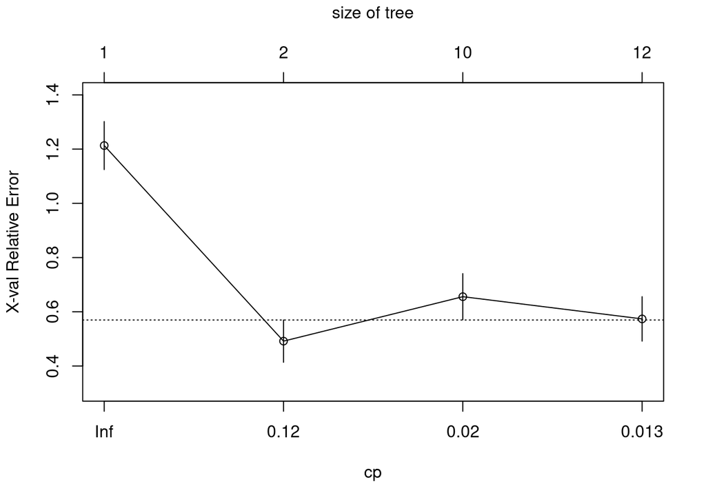

```r
# cross validation of the performance
plotcp(mod)
```

```r
# optimal hyperparameter
cp = mod$cptable[which.min(mod$cptable[,4]),1]
cp
```

```
## [1] 0.02459016
```

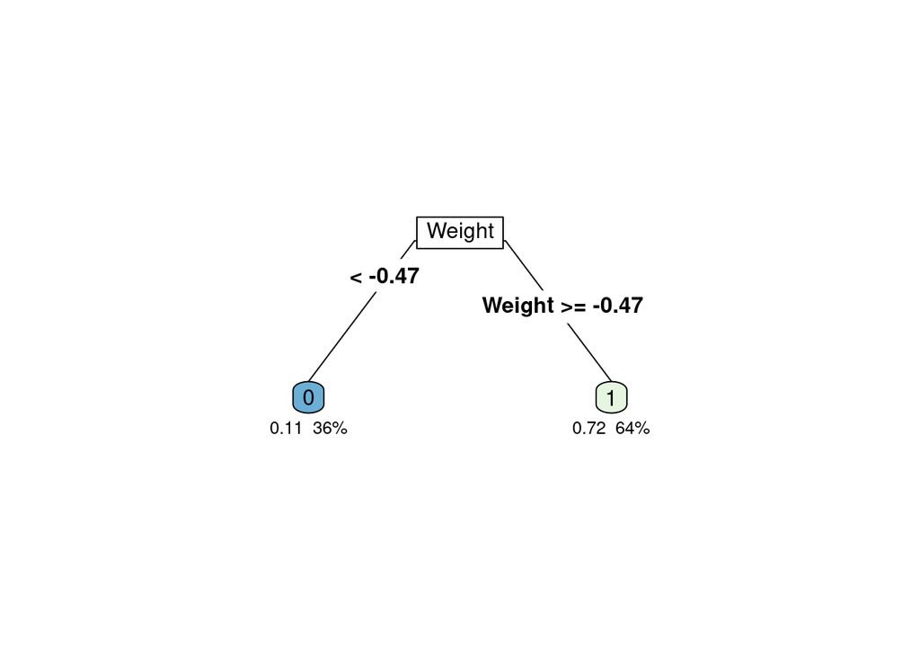

```r
# prune the tree using the manually selected hyperparamater cp
mod = prune(mod,cp=cp)

# pruned tree
rpart.plot(mod,type = 5,clip.right.labs = FALSE, branch = .3, under = TRUE)
```

```r
# calcualte misclassification rate:
pred = predict(mod,pp_test,type="class")
pred_in_sample = predict(mod,pp_train,type="class")

# Misclassification rate based on test data
mis_class_pruned = mean(pred != pp_test$labels)

# Misclassification rate  based on trainingt data (in-sample misclassification)
mis_class_pruned_in_sample =mean(pred_in_sample != pp_train$labels)

mis_class_pruned
```

```
## [1] 0.2604167
```

```r
mis_class_pruned_in_sample
```

```
## [1] 0.2213115
```

As a next step, we can compare the models:

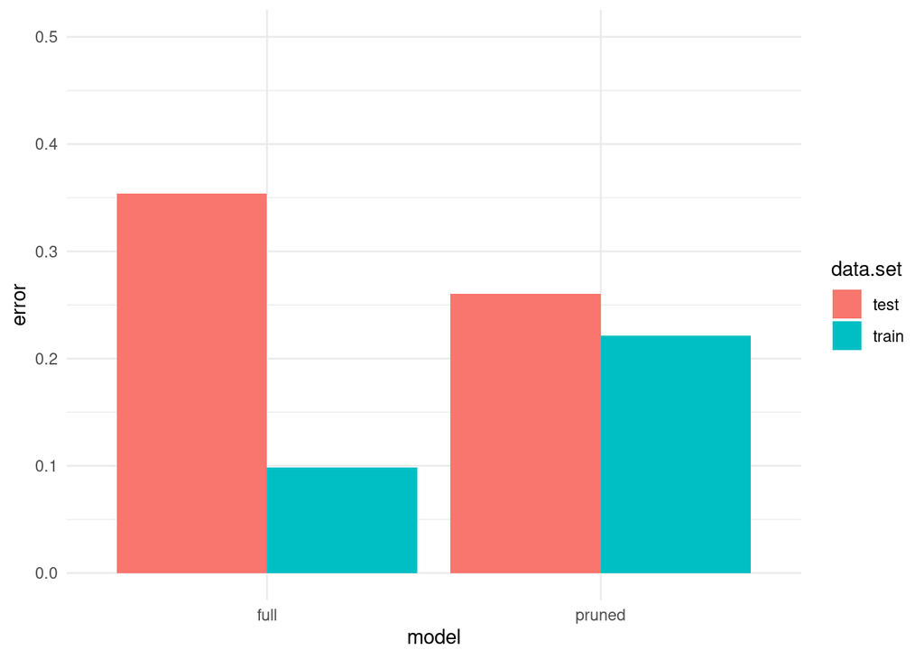

```r
# Compare the two models

df_miss_class = data.frame(
  model = c("full","full","pruned","pruned"),
  data.set = c("test","train","test","train"),
  error = c(mis_class_full,mis_class_full_in_sample,
            mis_class_pruned,mis_class_pruned_in_sample)
)

plot1 = ggplot(dat = df_miss_class) +
  geom_bar(stat="identity",
           aes(y = error,x = model,fill = data.set),
           position=position_dodge()) +
  theme_minimal() +
  ylim(0,0.5)

show(plot1)
```

```r
# Function to create confusion matrix

plot.cm = function(cmtable,angx = 0,angy = 0)
{
  plt <- as.data.frame(cmtable)

  plt$Prediction <- factor(plt$Prediction, levels=rev(levels(plt$Prediction)))

  ggplot(plt, aes(Prediction,Reference, fill= Freq)) +
    geom_tile() + geom_text(aes(label=Freq)) +
    scale_fill_gradient(low="white", high="#009194", limits = c(0,max(cmtable))) +
    labs(y = "Reference",x = "Prediction") +
    theme(axis.text.x = element_text(angle = angx, vjust = 0.5, hjust=0.5)) +
    theme(axis.text.y = element_text(angle = angy, vjust = -0.5, hjust=0.5)) +
    theme(text = element_text(size = 20))
}

# here i define a color palette to use as standard when plotting with ggplot
# this is purely for aesthetic reasons

cbp2 <- c("#000000", "#E69F00", "#56B4E9", "#009E73", "#F0E442", "#0072B2", "#D55E00", "#CC79A7")

scale_colour_discrete <- function(...)
{ scale_colour_manual(..., values = cbp2)
}
```

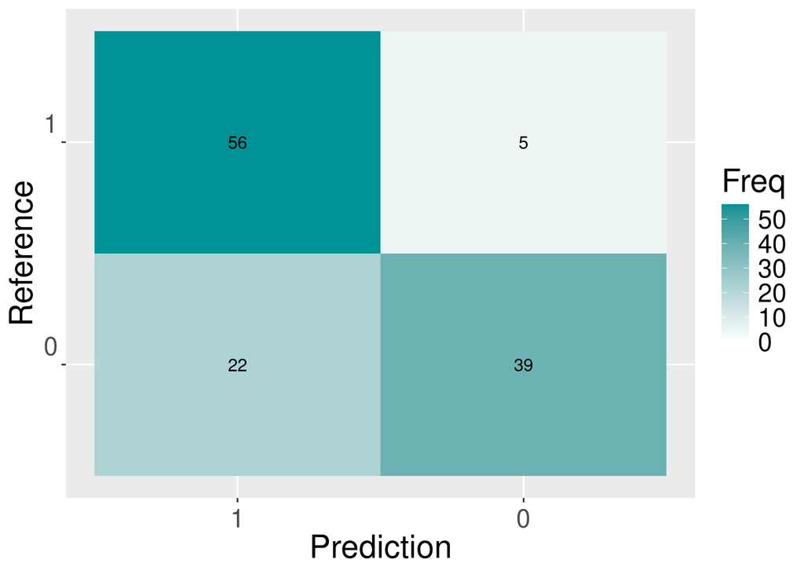

```r
# Confusion matrix for the pruned model
# note accuracy  = 1- misclassification rate
cm <- confusionMatrix(pred_in_sample, pp_train$labels)
plot.cm(cm$table)
```

```r
cm$byClass
```

```
##          Sensitivity          Specificity       Pos Pred Value
##            0.6393443            0.9180328            0.8863636
##       Neg Pred Value            Precision               Recall
##            0.7179487            0.8863636            0.6393443
##                   F1           Prevalence       Detection Rate
##            0.7428571            0.5000000            0.3196721
## Detection Prevalence    Balanced Accuracy
##            0.3606557            0.7786885
```

```r
# Summarize perfromance measures
cm_dat_dt = data.frame(RPart = cm$byClass)
cm_dat_dt %>%
  kbl() %>%
  kable_styling()
```

|  | RPart |
| --- | --- |
| Sensitivity | 0.6393443 |
| Specificity | 0.9180328 |
| Pos Pred Value | 0.8863636 |
| Neg Pred Value | 0.7179487 |
| Precision | 0.8863636 |
| Recall | 0.6393443 |
| F1 | 0.7428571 |
| Prevalence | 0.5000000 |
| Detection Rate | 0.3196721 |
| Detection Prevalence | 0.3606557 |
| Balanced Accuracy | 0.7786885 |

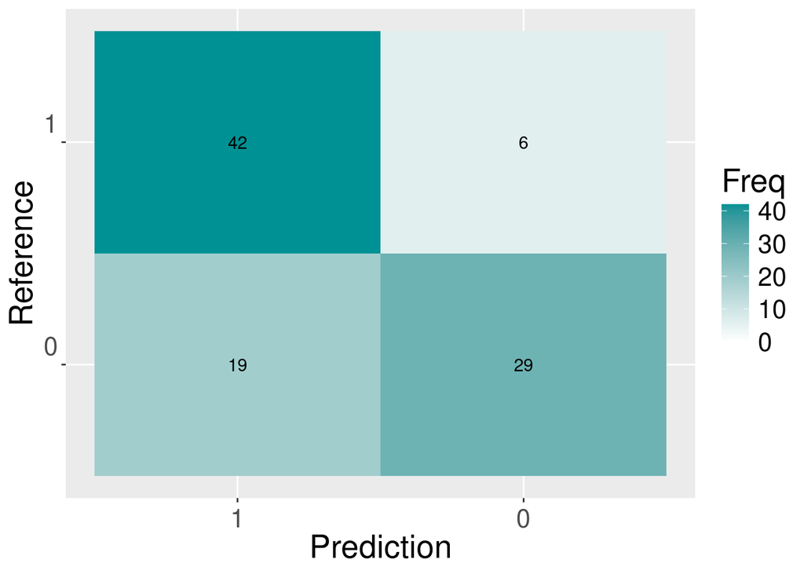

```r
cm <- confusionMatrix(pred, pp_test$labels)
plot.cm(cm$table)
```

```r
cm$byClass
```

```
##          Sensitivity          Specificity       Pos Pred Value
##            0.6041667            0.8750000            0.8285714
##       Neg Pred Value            Precision               Recall
##            0.6885246            0.8285714            0.6041667
##                   F1           Prevalence       Detection Rate
##            0.6987952            0.5000000            0.3020833
## Detection Prevalence    Balanced Accuracy
##            0.3645833            0.7395833
```

```r
# Summarize perfromance measures
cm_dat_dt = data.frame(RPart = cm$byClass)
cm_dat_dt %>%
  kbl() %>%
  kable_styling()
```

|  | RPart |
| --- | --- |
| Sensitivity | 0.6041667 |
| Specificity | 0.8750000 |
| Pos Pred Value | 0.8285714 |
| Neg Pred Value | 0.6885246 |
| Precision | 0.8285714 |
| Recall | 0.6041667 |
| F1 | 0.6987952 |
| Prevalence | 0.5000000 |
| Detection Rate | 0.3020833 |
| Detection Prevalence | 0.3645833 |
| Balanced Accuracy | 0.7395833 |